# Prototipo para alertas de homicidio

```r
library(tidyverse)
library(lubridate)
library(surveillance)
```

# Datos

Fuente de datos: https://elcri.men/es/datos.html, del Secretariado Ejecutivo del Sistema Nacional de Seguridad Pública.

```r
nm <- read_csv("./data/nm-fuero-comun-municipios.csv", progress = FALSE)
nm <- nm %>% mutate(date = ymd(paste0(date, '-01')))
tipo_homidicio <- c("FEMINICIDIO", "HOMICIDIO")
homicidios <- nm %>% filter(tipo %in% tipo_homidicio) %>%
    select(state_code, state, mun_code, municipio, date, count, population) %>%
    group_by(state_code, state, mun_code, municipio, date) %>%
    summarise(population = first(population), count = sum(count))
```

# Métodos de monitoreo: bayesiano simple

Consideramos modelos que se utilizan en epidemiología.

Referencia: https://cran.r-project.org/web/packages/surveillance/vignettes/surveillance.pdf

En particular, consideramos el método bayesiano de la referencia anterior:

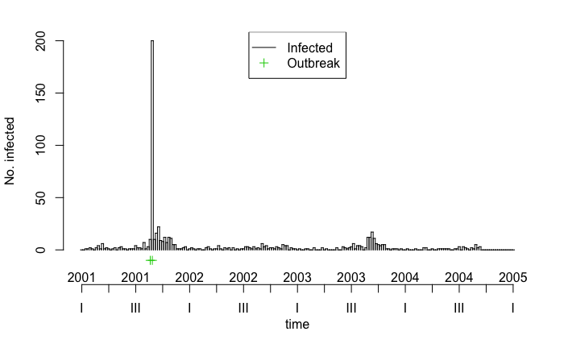

```r
data(k1)
plot(k1)
```

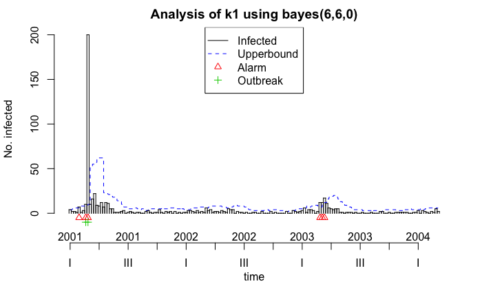

```r
# Evaluar de 27 a 192
k1_surveil <- algo.bayes(k1,
  control = list(range = 27:192, b = 0, w = 6, alpha = 0.01))
plot(k1_surveil)
```

Para aplicar este método, primero definimos:

- Valores de referencia para estimar parámetros del modelo, que son las observaciones pasadas de conteos de homicidios $y_i$.
- Región donde queremos crear predicciones, límites superiores, y detectar anomalías.

Una vez definido, el modelo para nuevas observaciones (ver referencia) $y_k$ es

- $P(y_k | \lambda)$ es Poisson con parmátro lambda
- $\lambda$ es Gamma con parámetros $(\alpha, \beta)$.

La posterior para $\lambda$ es Gamma con parámetros $(\alpha + \sum_i y_i, \beta + n)$, y la posterior predictiva es Poisson-Gamma con los mismos parámetros.

Una vez que calculamos la posterior predictiva, establecemos una alarma si la observación $y_k$ satisface $y_k > y_\alpha$, donde $y_\alpha$ es el cuantil $1- \alpha$ de la posterior predictiva.

En los ejemplos siguientes, pondremos

- $\alpha = 0.02$
- Observaciones de 6 meses anteriores para estimar parámetros, solo del año corriente.

# Ejemplos, método bayesiano

Consideramos tres municipios de Puebla:

```r
#puebla_edo <- filter(homicidios, state == "PUEBLA")
puebla_edo <- readRDS("data/puebla.rds")
puebla_edo %>% group_by(municipio) %>% summarise(count = sum(count)) %>%
    arrange(desc(count)) %>%
    filter(municipio %in% c("PUEBLA", "CHILCHOTLA", "HUAUCHINANGO"))
```

| municipio | count |
| --- | --- |
| PUEBLA | 982 |
| HUAUCHINANGO | 152 |
| CHILCHOTLA | 4 |

```r
huauchinango <- puebla_edo %>% filter(state == "PUEBLA", municipio == "HUAUCHINANGO")
puebla <- puebla_edo %>% filter(state == "PUEBLA", municipio == "PUEBLA")
chilchotla <- puebla_edo %>% filter(state =="PUEBLA", municipio == "CHILCHOTLA")
```

```r
source("./deteccion-homicidios.R")
```

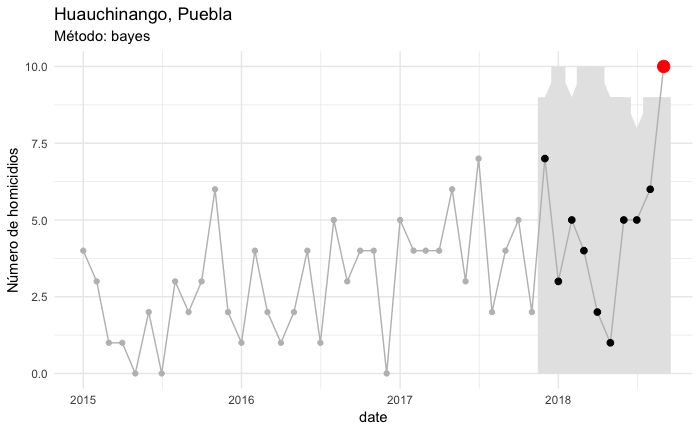

```r
monitor_huau <- monitor_bayes(huauchinango)
graf_monitor(monitor_huau)
```

```r
monitor_huau$data %>% tail
```

| state_code | state | mun_code | municipio | date | population | count | alerta | alerta_nivel | metadata |
| --- | --- | --- | --- | --- | --- | --- | --- | --- | --- |
| 21 | PUEBLA | 71 | HUAUCHINANGO | 2018-04-01 | 107811 | 2 | FALSE | 10 | {"tipo":"bayes","alpha":0.02,"b":0,"w":6,"periods":10,"hash_model":"da290a00d0edd1a9f06cd45a23fa038f"} |
| 21 | PUEBLA | 71 | HUAUCHINANGO | 2018-05-01 | 107898 | 1 | FALSE | 9 | {"tipo":"bayes","alpha":0.02,"b":0,"w":6,"periods":10,"hash_model":"da290a00d0edd1a9f06cd45a23fa038f"} |
| 21 | PUEBLA | 71 | HUAUCHINANGO | 2018-06-01 | 107986 | 5 | FALSE | 9 | {"tipo":"bayes","alpha":0.02,"b":0,"w":6,"periods":10,"hash_model":"da290a00d0edd1a9f06cd45a23fa038f"} |
| 21 | PUEBLA | 71 | HUAUCHINANGO | 2018-07-01 | 108072 | 5 | FALSE | 8 | {"tipo":"bayes","alpha":0.02,"b":0,"w":6,"periods":10,"hash_model":"da290a00d0edd1a9f06cd45a23fa038f"} |
| 21 | PUEBLA | 71 | HUAUCHINANGO | 2018-08-01 | 108158 | 6 | FALSE | 9 | {"tipo":"bayes","alpha":0.02,"b":0,"w":6,"periods":10,"hash_model":"da290a00d0edd1a9f06cd45a23fa038f"} |
| 21 | PUEBLA | 71 | HUAUCHINANGO | 2018-09-01 | 108244 | 10 | TRUE | 9 | {"tipo":"bayes","alpha":0.02,"b":0,"w":6,"periods":10,"hash_model":"da290a00d0edd1a9f06cd45a23fa038f"} |

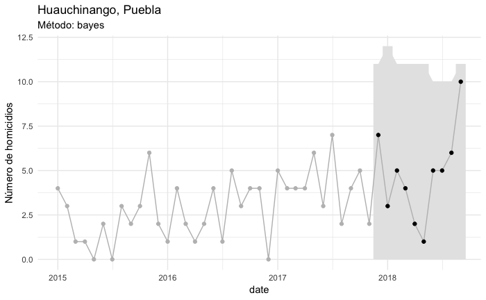

```r
monitor_huau <- monitor_bayes(huauchinango, alpha = 0.005)
graf_monitor(monitor_huau)
```

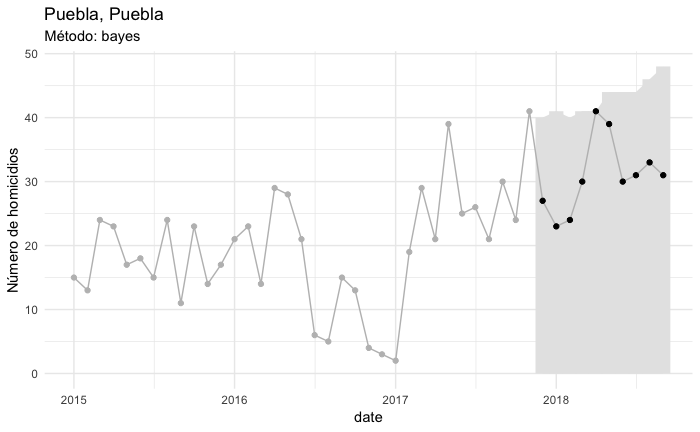

```r
monitor_pue <- monitor_bayes(puebla)
graf_monitor(monitor_pue)
```

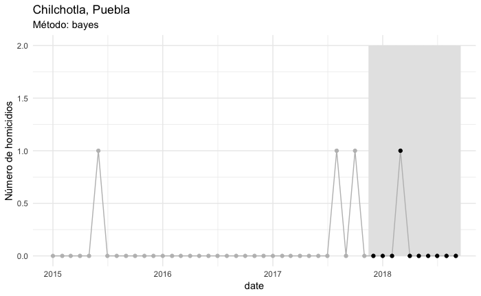

```r
monitor_chi <- monitor_bayes(chilchotla)
graf_monitor(monitor_chi)
```

# Métodos de monitoreo: Farrington

En la referencia del [paquete surveillance](https://www.jstatsoft.org/article/view/v070i10) se implementan otros métodos:

- CDC y otros: utilizan media, varianza y utilizan una aproximación normal simple.
- Farrington y variaciones: similar al modelo bayesiano, pero con un modelo para la media que puede incluir tendencia y estacionalidad. Es el método que se utiliza por agencias europeas de monitoreo.

1. Supongamos que los valores de referencia son $y_t$
2. Se ajusta un modelo Poisson sobredisperso a los datos de referencia, con
   $$E(y_t) = \mu_t, Var(y_t) = \phi \mu_t,$$
   donde $\phi$ es el parámetro de sobredispersión, y donde
   $$\log(\mu_k) = \alpha + \beta t$$
   sirve para modelar tendencia.
3. Se calculan pesos para los datos, reduciendo el peso de *outliers* según la distribución obtenida de los datos de referencia.
4. Se reajusta el modelo con los pesos calculados en el paso anterior
5. Para el paso de detección, usamos el método de Noufaily (2012) (ver referencia de paquete), donde la distribución de referencia para el nuevo valor $y_{t_0}$ es
   $$y_{t_0}\sim NB(\mu_{t_0}, \eta)$$
   donde $\eta= \frac{\mu_{t_0}}{\phi - 1}$.

Notas:

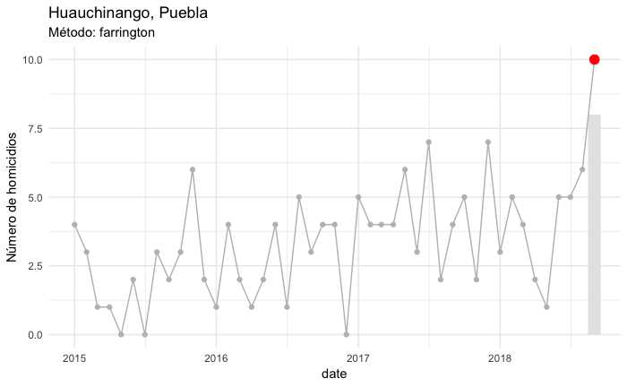

```r
monitor_huau <- monitor_farrington(huauchinango, alpha=0.05, periods = 1)
graf_monitor(monitor_huau)
```

```r
monitor_huau$data %>%  tail
```

| state_code | state | mun_code | municipio | date | population | count | alerta | alerta_nivel | metadata |
| --- | --- | --- | --- | --- | --- | --- | --- | --- | --- |
| 21 | PUEBLA | 71 | HUAUCHINANGO | 2018-04-01 | 107811 | 2 | NA | NA | {"tipo":"farrington","alpha":0.05,"b":2,"w":4,"periods":1,"limit":[5,3],"hash_model":"4cd92361e290511e116f70905177544c"} |
| 21 | PUEBLA | 71 | HUAUCHINANGO | 2018-05-01 | 107898 | 1 | NA | NA | {"tipo":"farrington","alpha":0.05,"b":2,"w":4,"periods":1,"limit":[5,3],"hash_model":"4cd92361e290511e116f70905177544c"} |
| 21 | PUEBLA | 71 | HUAUCHINANGO | 2018-06-01 | 107986 | 5 | NA | NA | {"tipo":"farrington","alpha":0.05,"b":2,"w":4,"periods":1,"limit":[5,3],"hash_model":"4cd92361e290511e116f70905177544c"} |
| 21 | PUEBLA | 71 | HUAUCHINANGO | 2018-07-01 | 108072 | 5 | NA | NA | {"tipo":"farrington","alpha":0.05,"b":2,"w":4,"periods":1,"limit":[5,3],"hash_model":"4cd92361e290511e116f70905177544c"} |
| 21 | PUEBLA | 71 | HUAUCHINANGO | 2018-08-01 | 108158 | 6 | NA | NA | {"tipo":"farrington","alpha":0.05,"b":2,"w":4,"periods":1,"limit":[5,3],"hash_model":"4cd92361e290511e116f70905177544c"} |
| 21 | PUEBLA | 71 | HUAUCHINANGO | 2018-09-01 | 108244 | 10 | TRUE | 8 | {"tipo":"farrington","alpha":0.05,"b":2,"w":4,"periods":1,"limit":[5,3],"hash_model":"4cd92361e290511e116f70905177544c"} |

```r
monitor_puebla <- monitor_farrington(puebla, periods = 10)
```

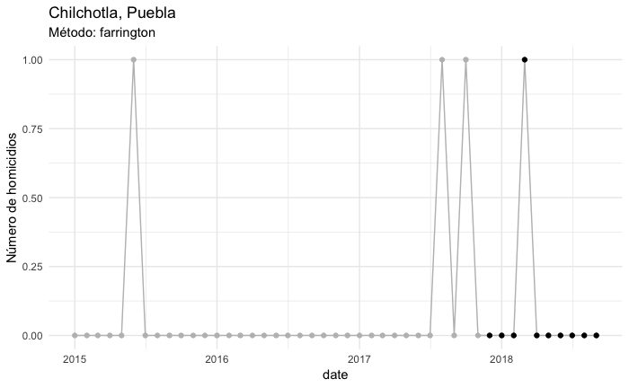

```r
monitor_chi <- monitor_farrington(chilchotla, alpha = 0.02, periods = 10)
graf_monitor(monitor_chi)
```

# Otros ejemplos

```r
#sinaloa_edo <- filter(homicidios, state == "SINALOA")
sinaloa_edo <- readRDS("data/sinaloa.rds")
sinaloa_edo %>% group_by(municipio) %>% summarise(count = sum(count)) %>%
    arrange(desc(count))
```

| municipio | count |
| --- | --- |
| CULIACÁN | 2449 |
| MAZATLÁN | 763 |
| AHOME | 544 |
| GUASAVE | 484 |
| NAVOLATO | 404 |
| EL FUERTE | 215 |
| MOCORITO | 180 |
| SALVADOR ALVARADO | 150 |
| ROSARIO | 132 |
| CONCORDIA | 128 |

[output cut: 8 more lines]

```r
dat_sinaloa <- sinaloa_edo %>% split(.$municipio)
monitores_sinaloa <-
    lapply(dat_sinaloa, function(df){
        monitor_mun <- monitor_farrington(df, alpha = 0.02, periods = 5)
        g <- graf_monitor(monitor_mun)
        g
    })
```

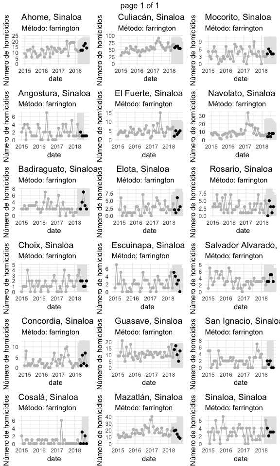

```r
library(gridExtra)
marrangeGrob(monitores_sinaloa, nrow = 6, ncol = 3)
```

```r
mex_edo <- filter(homicidios, state == "MICHOACÁN")
#sinaloa_edo <- readRDS("data/sinaloa.rds")
mex_edo %>% group_by(municipio) %>% summarise(count = sum(count)) %>%
    arrange(desc(count))
```

| municipio | count |
| --- | --- |
| MORELIA | 1490 |
| URUAPAN | 639 |
| ZAMORA | 504 |
| APATZINGÁN | 471 |
| LÁZARO CÁRDENAS | 437 |
| LA PIEDAD | 266 |
| SAHUAYO | 236 |
| MÚGICA | 205 |
| ZITÁCUARO | 179 |
| BUENAVISTA | 165 |

[output cut: 103 more lines]

```r
dat_mex <- mex_edo %>% split(.$municipio)
monitores_mex <-
    lapply(dat_mex, function(df){
        monitor_mun <- monitor_farrington(df, alpha = 0.02, periods = 5)
        g <- graf_monitor(monitor_mun)
        list(graf = g, monitor = monitor_mun)
    })
```

```r
tiene_alerta <- function(monitor){
    any(monitor$monitor$data$alerta == 1)
}
monitores_alarma <- keep(monitores_mex, tiene_alerta)
```

[output not shown]

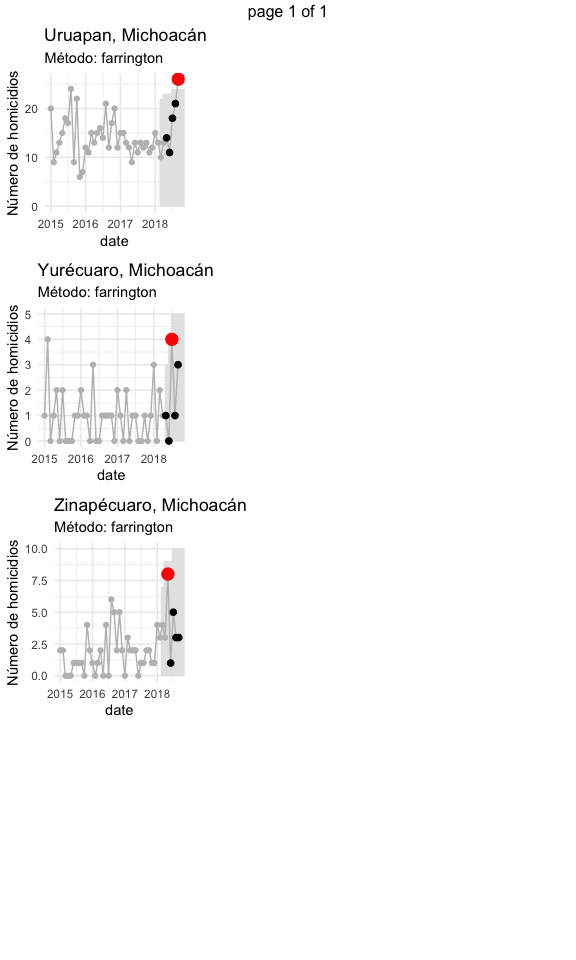

```r
graficas <- monitores_alarma %>% map(~.$graf)
marrangeGrob(graficas, nrow = 4, ncol = 3)
```

```r
mex_edo <- filter(homicidios, state == "VERACRUZ")
#sinaloa_edo <- readRDS("data/sinaloa.rds")
mex_edo %>% group_by(municipio) %>% summarise(count = sum(count)) %>%
    arrange(desc(count))
```

| municipio | count |
| --- | --- |
| VERACRUZ | 471 |
| CÓRDOBA | 362 |
| XALAPA | 326 |
| COATZACOALCOS | 320 |
| POZA RICA DE HIDALGO | 286 |
| PAPANTLA | 227 |
| ACAYUCAN | 195 |
| PÁNUCO | 194 |
| TUXPAN | 182 |
| TIERRA BLANCA | 177 |

[output cut: 204 more lines]

```r
dat_mex <- mex_edo %>% split(.$municipio)
monitores_mex <-
    lapply(dat_mex, function(df){
        monitor_mun <- monitor_farrington(df, alpha = 0.02, periods = 5)
        g <- graf_monitor(monitor_mun)
        list(graf = g, monitor = monitor_mun)
    })
```

```r
tiene_alerta <- function(monitor){
    any(monitor$monitor$data$alerta == 1)
}
monitores_alarma <- keep(monitores_mex, tiene_alerta)
```

[output not shown]

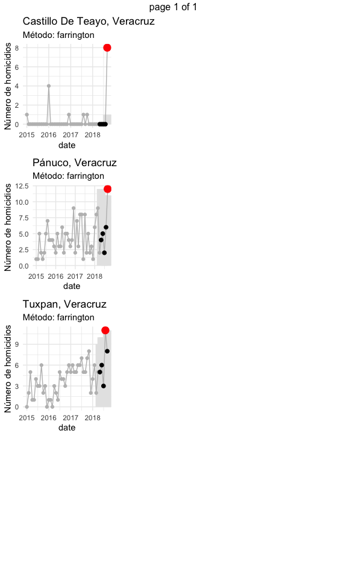

```r
graficas <- monitores_alarma %>% map(~.$graf)
marrangeGrob(graficas, nrow = 4, ncol = 3)
```

# Alertas para último mes

Para hacer rangos y alertas sobre todos los municipios, usamos un algoritmo mixto:

- Aplicamos primero el método Farrington flexible. Si el algoritmo converge, y hay suficientes datos (dos años atrás), utilizamos su salida.
- En otro caso, utilizamos el método bayesiano simple aplicado a los últimos 6 meses de datos.

Si hay suficientes datos hacia atrás, Farrington puede fallar cuando observamos conteos muy bajos (proporción alta de ceros).

```r
dat_nal <- homicidios %>% split(list(.$municipio, .$state), drop = TRUE)
length(dat_nal)
```

```
[1] 2469
```

```r
monitores_nal <-
    lapply(dat_nal, function(df){
        # farrington por default, a menos que haya menos de 2 años de datos
        # o no converja.
        monitor_mun <- monitor(df, alpha = 0.05, periods = 1)
        #g <- graf_monitor(monitor_mun)
        #list(graf = g, monitor = monitor_mun)
        monitor_mun
    })
tipos <- sapply(monitores_nal, function(monitor){ monitor$tipo })
table(tipos)
```

```
tipos
     bayes farrington
       561       1908
```

```r
conteos_bajo <- sapply(monitores_nal, function(monitor){ sum(tail(monitor$data$count,6)) < 5})
menos_1_año <- sapply(monitores_nal, function(monitor){ length(monitor$data$count) < 24})
data_frame(conteo_bajo = conteos_bajo, menos_1_año = menos_1_año, tipo = tipos) %>%
    group_by(menos_1_año, conteo_bajo, tipo) %>% tally() %>% spread(tipo, n)
```

| menos_1_año | conteo_bajo | bayes | farrington |
| --- | --- | --- | --- |
| FALSE | FALSE | NA | 675 |
| FALSE | TRUE | 23 | 1233 |
| TRUE | FALSE | 14 | NA |
| TRUE | TRUE | 524 | NA |

Alertas

```r
alertas <- sapply(monitores_nal, function(monitor){
    any(monitor$data$alerta, na.rm = TRUE) }
    )
table(alertas)
alertas_mun <- which(alertas)
alertas_mun
```

[output not shown]

```r
for(i in 1:length(alertas_mun)){
    print(graf_monitor(monitores_nal[[alertas_mun[i]]]))
}
```

[output not shown]

# References

Höhle, Michael. 2007. “Surveillance: An R Package for the Monitoring of Infectious Diseases.” *Computational Statistics* 22 (4): 571–82. https://doi.org/10.1007/s00180-007-0074-8.

Yang, Eunjoo, Hyun Woo Park, Yeon Hwa Choi, Jusim Kim, Lkhagvadorj Munkhdalai, Ibrahim Hussein Musa, and Keun Ho Ryu. 2018. “A Simulation-Based Study on the Comparison of Statistical and Time Series Forecasting Methods for Early Detection of Infectious Disease Outbreaks.” In *International Journal of Environmental Research and Public Health*.